# JASA_Realdata_Melanoma_PCoA

Ziyi Wang

2026-03-30

# Melanoma anti-PD-1 - The second real data

## Wilcoxon test + PCoA

### Load Packages/Functions

```r
suppressPackageStartupMessages({
  library(knitr)
  library(CATMicrobiome)
  library(mixtools)
  library(devtools)
  library(KScorrect)
  library(adaptMT)
  library(AdaPTGMM)
  library(splines2)
  library(dplyr)
  library(ape)
  library(phyloseq)
  library(ggplot2)
  library(tidyr)
  library(coin)
  library(ggrepel)
  library(IHW)
  library(FDRreg)
  library(OrderShapeEM)
  library(chai)
})
```

### Load the raw data and pre-processing the data

**Note**: The pro-processing part and model fitting chunk could be time-consuming. We saved the processed data together with the organized results after fitting the models. When knitting this HTML file, we loaded the **Gopalakrishnan_16s_PCoA_env.RData** file directly and generated the plots from it.

However, for verification or reproducibility, you can also run each pre-processing chunk and/or model-fitting chunk one by one, while skiping the chunk that loads the .RData file. This should produce the same results.

```r
#################### Load data from package CATMicrobiome ##############
otuPath <- system.file("extdata","d1OTUtable.csv",
                       package = "CATMicrobiome")
otutable <- read.csv(otuPath,header=TRUE,row.names = 1)

taxonomyPath <- system.file("extdata","d1Taxonomy.csv",
                            package = "CATMicrobiome")
taxonomy <- read.csv(taxonomyPath,header=TRUE,row.names = 1)

metaPath <- system.file("extdata","d1Meta.csv",
                        package = "CATMicrobiome")
metaData <- read.csv(metaPath,header=TRUE,row.names = 1)

treePath <- system.file("extdata","d1Tree.tree",
                        package = "CATMicrobiome")
tree <- read.tree(treePath)

otus_tree   <- tree$tip.label       # 1437
otus_tax    <- rownames(taxonomy)   # 1455
otus_keep   <- intersect(otus_tree, otus_tax)   # Keep 1437

# Prune tree and taxonomy
tree <- keep.tip(tree, otus_keep)
taxonomy <- taxonomy[otus_keep, , drop = FALSE]
taxonomy <- taxonomy[match(tree$tip.label, rownames(taxonomy)), , drop = FALSE]  # reorder to tree tips
otutable <- otutable[otus_keep, , drop = FALSE]
# 1437 tips

OTU <- otu_table(as.matrix(otutable), taxa_are_rows = TRUE)
TAX <- tax_table(as.matrix(taxonomy))
SAM <- sample_data(metaData)
TR  <- phy_tree(tree)

############### Build phyloseq-class objects ################
ps <- phyloseq(OTU, TAX, SAM, TR)

###################### Aggregate into Family level #######################
family <- tax_glom(ps, taxrank='family')

###################### Abundance table #######################
cs <- colSums(otu_table(family))
cs[cs == 0] <- 1
family_abun <- sweep(otu_table(family), 2, cs, "/") * 100    # family x subjects

# Transpose for modeling (subjects × species)
t_abun <- t(family_abun)     # 43 x 76

########################## Outcome ###################################
outcome <- factor(sample_data(family)$BinOutcomes, levels = c("NR","R"))
table(outcome)
```

### Get the side information - PCoA

```r
# Calculate the cophenetic distances from phylogentic tree at family level
family_D <- cophenetic(phy_tree(family))
# 76 x 76

# Fit the PCoA
family_pcoa <- cmdscale(family_D, k = 2)
```

### Generating the p-value/z-value

```r
p_z_values <- sapply(colnames(t_abun), function(feature) {
  features <- t_abun[, feature, drop = FALSE]
  wilcox <- wilcox_test(features[,1] ~ outcome)

  p_value <- pvalue(wilcox)
  z_value <- statistic(wilcox)

  return(c(p_value = p_value, z_value = z_value))
}, simplify = "matrix")
p_z_values <- t(p_z_values)

p_value <- p_z_values[,1]
z_value <- p_z_values[,2]
```

### Load the processed data

The processed data included:

- **z_value**: the z-statistics from wilcoxon test of each family between NR vs R.
- **p_value**: the p-value from wilcoxon test of each family between NR vs R.
- **family_pcoa**: the side information. The two dimensional PCoA of cophenetic distances from phylogentic tree at family level.
- **t_abun**: the relative abundance table of this dataset at family level.
- **outcome**: the outcome (NR or R) of this dataset.
- **family**: the phyloseq-class objects saving otu table, taxon table, metadata information and tree structure.
- **chai_family_pcoa**: (chai) output with wilcoxon z_statistics and family_pcoa (side information) as inputs.
- **gopa_fam_16s**: the summary table saving the number of selections of every method at different q, with wilcoxon z + family_pcoa.
- **gopa_fam_16s_long**: the long table version of gopa_fam_16s for plot purpose.
- **chai_family_pcoa_DES**: (chai) output with DESeq wald_statistics and family_pcoa (side information) as inputs.
- **gopa_fam_16s_DES**: the summary table saving the number of selections of every method at different q, with DESeq2 wald-stat + family_pcoa.
- **gopa_fam_16s_DES_long**: the long table version of gopa_fam_16s_DES for plot purpose.

```r
load("./chai_env/Gopalakrishnan_16s_PCoA_env.RData")
```

### Fit the models

```r
q_levels <- seq(0.01, 0.10, by = 0.01)

################## chai #######################
set.seed(123)
chai_family_pcoa <- chai(z_value, family_pcoa, B = 100)
chai_rejs <- sapply(q_levels, function(q) {
  length(clfdrselect(chai_family_pcoa$clFDR, q, 1))
})


########################## Adapt-glm ##########################
x <- data.frame(family_pcoa)
formula_ns <- list("~ns(X1, df = 2) + ns(X2, df = 2)",
                   "~ns(X1, df = 4) + ns(X2, df = 4)",
                   "~ns(X1, df = 6) + ns(X2, df = 6)")

glm_ns <- adapt_glm(x, pvals = p_value, alphas=q_levels,
                    pi_formulas = formula_ns, mu_formulas = formula_ns)
adapt_glm_ns_rej <- glm_ns$nrejs[1:10]

########################## Adapt-gmm-p ##########################
gmm_ns_p <- adapt_gmm(x, pvals = p_value,  alphas=q_levels,
                      beta_formulas = formula_ns)
adapt_gmm_p_ns_rej <- gmm_ns_p$nrejs[1:10]

########################## Adapt-gmm-z ##########################
gmm_ns_z <- adapt_gmm(x, z = z_value, alphas=q_levels,
                      beta_formulas = formula_ns, testing = "two_sided")
adapt_gmm_z_ns_rej <- gmm_ns_z$nrejs[1:10]

########################## OrderShapeEM ##########################
ordershape_x1 <- OrderShapeEM(pvals = p_value, order.var = family_pcoa[,1],
                              OrderShapeEM.control(trace = TRUE))
ordershapeem_x1_rejs <- sapply(q_levels, function(q) {
  sum(ordershape_x1$fdr <= q)
})

ordershape_x2 <- OrderShapeEM(pvals = p_value, order.var = family_pcoa[,2],
                              OrderShapeEM.control(trace = TRUE))
ordershapeem_x2_rejs <- sapply(q_levels, function(q) {
  sum(ordershape_x2$fdr <= q)
})


########################## FDRreg ##########################
set.seed(123)
fdr_theo <- FDRreg(z_value, family_pcoa, nulltype = 'theoretical')
rdrreg_rejs <- sapply(q_levels, function(q) {
  length(which(fdr_theo$FDR <= q))
})

########################## IHW ##########################
set.seed(123)
ihw_1_rejs <- sapply(q_levels, function(q) {
  ihw <- ihw(pvalues = p_value, covariates = family_pcoa[,1], alpha = q, nbins = 5)
  rejections(ihw)
})

ihw_2_rejs <- sapply(q_levels, function(q) {
  ihw <- ihw(pvalues = p_value, covariates = family_pcoa[,2], alpha = q, nbins = 5)
  rejections(ihw)
})


########################## BH ##########################
p_adjusted <- p.adjust(p_value, method = "BH")
bh_rejs <- sapply(q_levels, function(q) {
  length(which(p_adjusted <= q))
})

# combine into data frame
gopa_fam_16s <- data.frame(
  q = q_levels,
  chai = chai_rejs,
  adapt_glm = adapt_glm_ns_rej,
  adapt_gmm_p = adapt_gmm_p_ns_rej,
  adapt_gmm_z = adapt_gmm_z_ns_rej,
  OrderShapeEM_x1 = ordershapeem_x1_rejs,
  OrderShapeEM_x2 = ordershapeem_x2_rejs,
  FDRreg = rdrreg_rejs,
  IHW_x1 = ihw_1_rejs,
  IHW_x2 = ihw_2_rejs,
  BH = bh_rejs
)


# converge into long format for visualization
gopa_fam_16s_long <- gopa_fam_16s %>%
  tidyr::pivot_longer(
    cols = -q,
    names_to = "Method",
    values_to = "Rejections"
  ) %>%
  mutate(Method = as.character(Method))
```

### Visualization

Define the plotting functions

```r
# ---------- color helpers ----------
blend_color <- function(col, target = "white", amount = 0.4) {
  a <- grDevices::col2rgb(col) / 255
  b <- grDevices::col2rgb(target) / 255
  out <- (1 - amount) * a + amount * b
  grDevices::rgb(out[1,], out[2,], out[3,])
}

variant_shades <- function(base_col, K = 12) {
  grDevices::colorRampPalette(c(
    blend_color(base_col, "white", 0.55),
    base_col,
    blend_color(base_col, "black", 0.25)
  ))(K)
}

make_method_palette <- function(methods, K = 12) {
  fixed <- c(
    chai        = "red",
    adapt_glm   = "#FF7F0E",
    adapt_gmm_z = "#2CA02C",
    adapt_gmm_p = "#9467BD",
    FDRreg      = "#8C564B",
    BH          = "black"
  )

  family_base <- c(
    OrderShapeEM = "#1F77B4",  # blue family
    IHW          = "#17BECF"   # teal family
  )

  ord_shades <- variant_shades(family_base["OrderShapeEM"], K = K)
  ihw_shades <- variant_shades(family_base["IHW"],          K = K)

  methods <- unique(as.character(methods))
  pal <- setNames(rep("#7F7F7F", length(methods)), methods)  # fallback grey

  for (m in methods) {
    if (m %in% names(fixed)) {
      pal[m] <- fixed[m]
      next
    }

    base <- sub("_x\\d+$", "", m)
    idx  <- suppressWarnings(as.integer(sub(".*_x", "", m)))

    if (base %in% names(family_base)) {
      if (is.na(idx)) {
        pal[m] <- family_base[base]  # e.g. "OrderShapeEM" with no suffix
      } else {
        idx <- max(1L, min(idx, K))
        pal[m] <- if (base == "OrderShapeEM") ord_shades[idx] else ihw_shades[idx]
      }
    }
  }

  pal
}

method_order <- function(methods) {
  methods <- unique(as.character(methods))
  core <- c("chai","adapt_glm","adapt_gmm_z","adapt_gmm_p","FDRreg")

  sort_family <- function(base) {
    fam <- methods[grepl(paste0("^", base, "(_x\\d+)?$"), methods)]
    base_present <- base %in% fam
    vars <- fam[grepl("_x\\d+$", fam)]
    if (length(vars)) {
      idx <- suppressWarnings(as.integer(sub(".*_x", "", vars)))
      vars <- vars[order(idx)]
    }
    c(if (base_present) base else character(0), vars)
  }

  out <- c(core, sort_family("OrderShapeEM"), sort_family("IHW"), "BH")
  out <- unique(out)
  out[out %in% methods]
}

# ---------- plotting function (labels, no legend) ----------
library(ggrepel)
library(stringr)

plot_rejections_vs_q <- function(long_table, # title = "Number of Discoveries vs q",
                                 K_variants = 12, x_breaks = NULL,
                                 method_font = 5.5) {

  ord <- method_order(long_table$Method)
  long_table <- long_table %>% mutate(Method = factor(Method, levels = ord))
  pal <- make_method_palette(levels(long_table$Method), K = K_variants)

  endpoints <- long_table %>%
    group_by(Method) %>%
    filter(q == max(q, na.rm = TRUE)) %>%
    slice_tail(n = 1) %>%
    ungroup() %>%
    mutate(label = as.character(Method))

  x_rng   <- range(long_table$q, na.rm = TRUE)
  x_nudge <- diff(x_rng) * 0.03

  p <- ggplot(long_table, aes(x = q, y = Rejections, group = Method, color = Method)) +
    geom_line(linewidth = 0.9, na.rm = TRUE) +
    geom_point(size = 1.8, na.rm = TRUE) +
    ggrepel::geom_text_repel(
      data = endpoints,
      aes(label = label),
      size = method_font,
      nudge_x = x_nudge,
      hjust = 0,
      direction = "y",
      segment.size = 0.2,
      box.padding = 0.15,
      point.padding = 0.10,
      min.segment.length = 0,
      max.overlaps = Inf,
      seed = 1,
      show.legend = FALSE
    ) +
    scale_color_manual(values = pal, breaks = ord) +
    labs(# title = title,
      x = "q level", y = "Number of Rejections") +
    coord_cartesian(clip = "off") +
    theme_minimal() +
    theme(
      legend.position = "none",
      plot.margin = margin(5.5, 60, 5.5, 5.5),
      axis.title.x = element_text(size = 14),
      axis.title.y = element_text(size = 14),
      axis.text.x  = element_text(size = 12),
      axis.text.y  = element_text(size = 12)
    )

  if (!is.null(x_breaks)) {
    p <- p + scale_x_continuous(breaks = x_breaks, expand = expansion(mult = c(0.02, 0.18)))
  } else {
    p <- p + scale_x_continuous(expand = expansion(mult = c(0.02, 0.18)))
  }

  p
}
```

##### The line chart

Fit the above function to get the line chart.

```r
p_PCoA <- plot_rejections_vs_q(gopa_fam_16s_long,
                              x_breaks = sort(unique(gopa_fam_16s_long$q)))
```

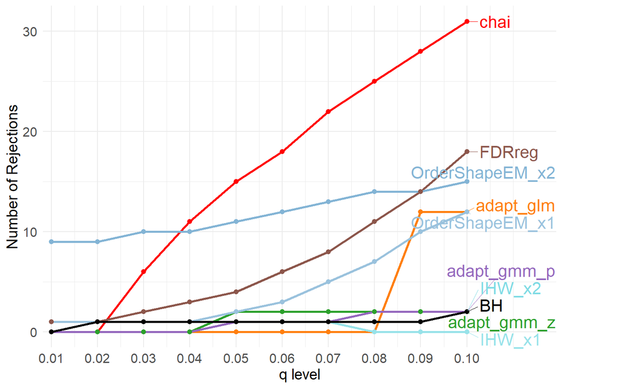

```r
p_PCoA
```

## DESeq2 + PCoA

### Fit the DESeq2 workflow to get wald-statistics and p-value

```r
library(DESeq2)
set.seed(123)
cts <- as(otu_table(family), "matrix")

md  <- as(sample_data(family), "data.frame")
md$BinOutcomes <- factor(md$BinOutcomes, levels = c("NR", "R"))

dds <- DESeqDataSetFromMatrix(countData = cts, colData = md,
                              design = ~ BinOutcomes)
dds_res <- DESeq(dds)
res <- results(dds_res, alpha = 0.05)
summary(res)
```

```
##
## out of 75 with nonzero total read count
## adjusted p-value < 0.05
## LFC > 0 (up)       : 6, 8%
## LFC < 0 (down)     : 1, 1.3%
## outliers [1]       : 0, 0%
## low counts [2]     : 1, 1.3%
## (mean count < 0)
## [1] see 'cooksCutoff' argument of ?results
## [2] see 'independentFiltering' argument of ?results
```

```r
DES_stat <- res$stat
DES_p <- res$pvalue
```

### Fit the models

```r
q_levels <- seq(0.01, 0.10, by = 0.01)

################## chai #######################
set.seed(123)
chai_family_pcoa_DES <- chai(DES_stat, family_pcoa, B = 100)
chai_rejs <- sapply(q_levels, function(q) {
  length(clfdrselect(chai_family_pcoa_DES$clFDR, q, 1))
})

########################## Adapt-glm ##########################
x <- data.frame(family_pcoa)
formula_ns <- list("~ns(X1, df = 2) + ns(X2, df = 2)",
                   "~ns(X1, df = 4) + ns(X2, df = 4)",
                   "~ns(X1, df = 6) + ns(X2, df = 6)")

glm_ns_DES <- adapt_glm(x, pvals = DES_p, alphas=q_levels,
                        pi_formulas = formula_ns, mu_formulas = formula_ns)

adapt_glm_ns_rej <- glm_ns_DES$nrejs[1:10]

########################## Adapt-gmm-p ##########################
gmm_ns_p_DES <- adapt_gmm(x, pvals = DES_p,  alphas=q_levels,
                      beta_formulas = formula_ns)
adapt_gmm_p_ns_rej <- gmm_ns_p_DES$nrejs[1:10]

########################## Adapt-gmm-z ##########################
gmm_ns_z_DES <- adapt_gmm(x, z = DES_stat, alphas=q_levels,
                      beta_formulas = formula_ns, testing = "two_sided")
adapt_gmm_z_ns_rej <- gmm_ns_z_DES$nrejs[1:10]

########################## OrderShapeEM ##########################
ordershape_x1_DES <- OrderShapeEM(pvals = DES_p, order.var = family_pcoa[,1],
                              OrderShapeEM.control(trace = TRUE))
ordershapeem_x1_rejs <- sapply(q_levels, function(q) {
  sum(ordershape_x1_DES$fdr <= q)
})

ordershape_x2_DES <- OrderShapeEM(pvals = DES_p, order.var = family_pcoa[,2],
                              OrderShapeEM.control(trace = TRUE))
ordershapeem_x2_rejs <- sapply(q_levels, function(q) {
  sum(ordershape_x2_DES$fdr <= q)
})


########################## FDRreg ##########################
set.seed(123)
fdr_theo_DES <- FDRreg(DES_stat, family_pcoa, nulltype = 'theoretical')
rdrreg_rejs <- sapply(q_levels, function(q) {
  length(which(fdr_theo_DES$FDR <= q))
})

########################## IHW ##########################
set.seed(123)
ihw_1_rejs <- sapply(q_levels, function(q) {
  ihw <- ihw(pvalues = DES_p, covariates = family_pcoa[,1], alpha = q, nbins = 5)
  rejections(ihw)
})

ihw_2_rejs <- sapply(q_levels, function(q) {
  ihw <- ihw(pvalues = DES_p, covariates = family_pcoa[,2], alpha = q, nbins = 5)
  rejections(ihw)
})


########################## BH ##########################
p_adjusted_DES <- p.adjust(DES_p, method = "BH")
bh_rejs <- sapply(q_levels, function(q) {
  length(which(p_adjusted_DES <= q))
})

# combine into data frame
gopa_fam_16s_DES <- data.frame(
  q = q_levels,
  chai = chai_rejs,
  adapt_glm = adapt_glm_ns_rej,
  adapt_gmm_p = adapt_gmm_p_ns_rej,
  adapt_gmm_z = adapt_gmm_z_ns_rej,
  OrderShapeEM_x1 = ordershapeem_x1_rejs,
  OrderShapeEM_x2 = ordershapeem_x2_rejs,
  FDRreg = rdrreg_rejs,
  IHW_x1 = ihw_1_rejs,
  IHW_x2 = ihw_2_rejs,
  BH = bh_rejs
)


# into long format
gopa_fam_16s_DES_long <- gopa_fam_16s_DES %>%
  tidyr::pivot_longer(
    cols = -q,
    names_to = "Method",
    values_to = "Rejections"
  ) %>%
  mutate(Method = as.character(Method))
```

### Visualization

##### The line chart

Fit the defined function to get the line chart.

```r
p_PCoA_DES <- plot_rejections_vs_q(gopa_fam_16s_DES_long,
                                   x_breaks = sort(unique(gopa_fam_16s_DES_long$q)))
```

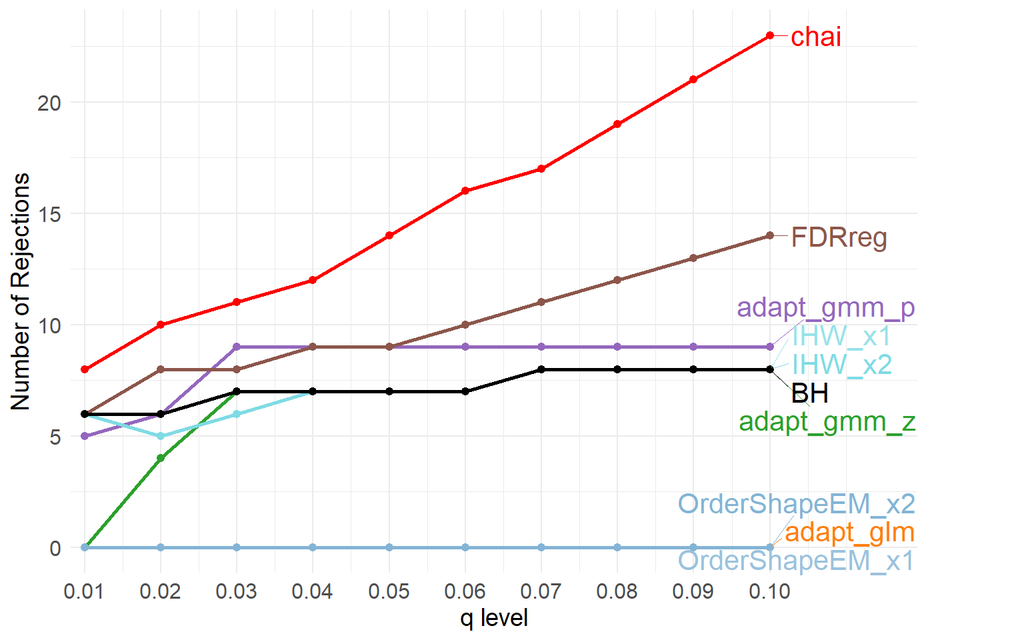

```r
p_PCoA_DES
```

##### The phylogentic tree

```r
library(ggtree)
library(ggtreeExtra)
library(ggnewscale)

# Define a function to clean the feature name
clean_taxon <- function(x) {
  x %>%
    as.character() %>%
    str_replace("^.*?__", "") %>%        # Remove k__/f__/g__
    str_replace_all("\\[|\\]", "") %>%   # Remove []
    str_squish()                         # Remove extra space
}

# Get the indices of the features that selected by chai, at q = 0.05
chai_DES_sel <- clfdrselect(chai_family_pcoa_DES$clFDR, 0.05, 1)
# Get the chai selected OTU IDs
sel_otus_DES <- rownames(res)[chai_DES_sel]

# Get the indices of the features that selected by BH, at q = 0.05
p_adjusted_DES <- p.adjust(DES_p, method = "BH")
DES_bh <- which(p_adjusted_DES <= 0.05)
# Get the BH selected OTU IDs
sel_otus_BH <- rownames(res)[DES_bh]

# map labels for ALL tips (not only selected)
tax_all <- as.data.frame(tax_table(family))
tax_all$OTU <- rownames(tax_all)

# Prepare the annotation
rank_to_show <- "family"
anno_DES <- tax_all %>%
  mutate(
    # clean the family names
    raw = .data[[rank_to_show]],
    clean = clean_taxon(raw),
    tip_label = ifelse(is.na(clean) | clean == "", OTU, clean),

    # clean the phylum names (for annotation)
    phylum_clean = clean_taxon(phylum),

    # tip color
    tip_color = dplyr::case_when(
      OTU %in% sel_otus_DES & OTU %in% sel_otus_BH ~ "both",
      OTU %in% sel_otus_DES & !(OTU %in% sel_otus_BH) ~ "chai_only",
      !(OTU %in% sel_otus_DES) & OTU %in% sel_otus_BH ~ "BH_only",
      TRUE ~ "neither"
    )  ) %>%
  dplyr::select(OTU, tip_label, phylum_clean, tip_color) %>%
  distinct(OTU, .keep_all = TRUE)

tr_all <- phy_tree(family)
tr <- ape::as.phylo(tr_all)

# Get the basic circular tree plot
p <- ggtree::ggtree(tr, layout = "circular", size = 0.5)

p1 <- p %<+% anno_DES

# Add phylum annotation
p2 <- p1 +
  new_scale_fill() +
  ggtreeExtra::geom_fruit(
    geom = geom_tile,
    mapping = aes(fill = phylum_clean),
    width = 0.2,
    offset = 0.05
  ) +
  labs(fill = "phylum")

# Add tip labels
p3 <- p2 +
  geom_tiplab(
    aes(label = tip_label, color = tip_color),
    size = 2,
    offset = 0.02,          # distance between text and color block
    show.legend = FALSE
  ) +
  scale_color_manual(
    name   = "Tip label group",
    values = c(chai_only="red", BH_only="blue", both="green", neither="black"),
    breaks = c("chai_only", "BH_only", "both", "neither"),
    labels = c("Only in chai", "Only in DESeq2", "In both", "Neither"),
    drop   = FALSE
  ) +
  # labs(title = "Phylogenetic tree with selected families by chai on DESeq2 z with PCoA") +
  theme(legend.position = "right")

legend_df <- data.frame(
  x = NA_real_, y = NA_real_,
  tip_color = factor(c("chai_only","BH_only","both","neither"),
                     levels = c("chai_only","BH_only","both","neither"))
)

# Add tip label group legend
p4 <- p3 +
  geom_point(
    data = legend_df,
    aes(x = x, y = y, color = tip_color),
    inherit.aes = FALSE,
    size = 3
  ) +
  guides(color = guide_legend(override.aes = list(alpha = 1))) +
  theme(legend.position = "right")
```

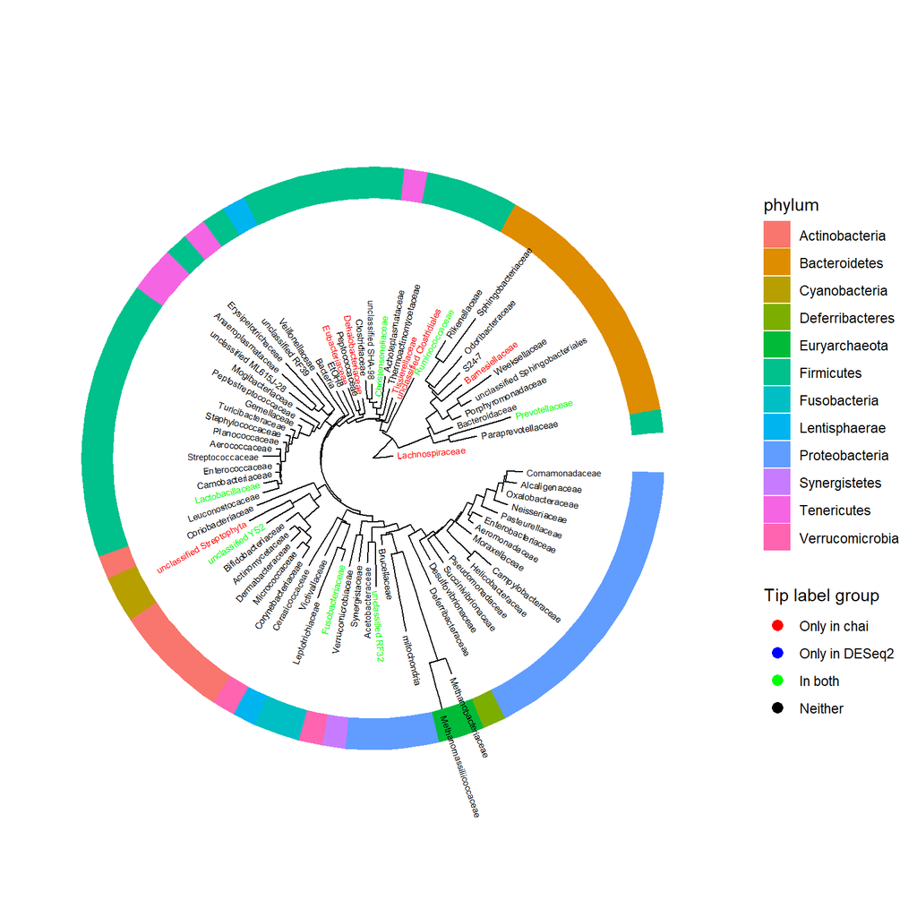

```r
p4
```